# SI_02_GRANT_US_ORG_EIN

Grantee EIN · Identifier report

## Overview

**Description**

EIN of recipient

**Table**

`SI-P02-T01-GRANTS-US-ORGS-GOVTS` (many)

**Location code**

`SCHED-I-PART-02-LINE-01-COL-B`

**Family**

`SCHED-I-PART-02-LINE-01-COL-B`

**Data type**

numeric (xsd: , EINType)

**Scope**

PC

**Status**

unreviewed

3

xpaths mapped (2 observed)

475,636

filings with a value

2009–2024

tax years observed

1

open flags (0 errors)

## Flags

| Severity | Flag | Xpath | Detail |
| --- | --- | --- | --- |
| ⓘ info | `UNOBSERVED` | IRS990ScheduleI/Form990ScheduleIPartII/RecipientTable/EINOfRecipient | never observed in TY2009-2024 filings |

## Xpaths

All mapped xpaths (under /Return/ReturnData or /Return/ReturnHeader), oldest first. Charts label each series by its xpath.

| Xpath | Form | Chart label | First year | Last year | Versions | Filings | Repeats in |
| --- | --- | --- | --- | --- | --- | --- | --- |
| IRS990ScheduleI/RecipientTable/EINOfRecipient | Sched I | same | 2009 | 2012 | 17 | 61,691 | 51.1% |
| IRS990ScheduleI/RecipientTable/RecipientEIN | Sched I | same | 2013 | 2024 | 37 | 413,945 | 50.6% |
| IRS990ScheduleI/Form990ScheduleIPartII/RecipientTable/EINOfRecipient | Sched I | …uleI/Form990ScheduleIPartII/RecipientTable/EINOfRecipient |  |  |  | 0 |  |

## Coverage

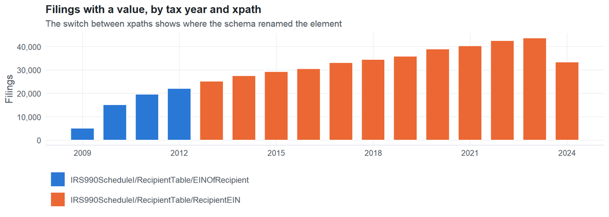

**Table view**

Table view: filings by tax year and series

| Tax year | IRS990ScheduleI/RecipientTable/EINOfRecipient | IRS990ScheduleI/RecipientTable/RecipientEIN |
| --- | --- | --- |
| 2009 | 5,012 | 0 |
| 2010 | 15,085 | 0 |
| 2011 | 19,583 | 0 |
| 2012 | 22,011 | 0 |
| 2013 | 0 | 25,150 |
| 2014 | 0 | 27,473 |
| 2015 | 0 | 29,165 |
| 2016 | 0 | 30,466 |
| 2017 | 0 | 33,120 |
| 2018 | 0 | 34,415 |
| 2019 | 0 | 35,747 |
| 2020 | 0 | 38,866 |
| 2021 | 0 | 40,219 |
| 2022 | 0 | 42,496 |
| 2023 | 0 | 43,564 |
| 2024 | 0 | 33,264 |

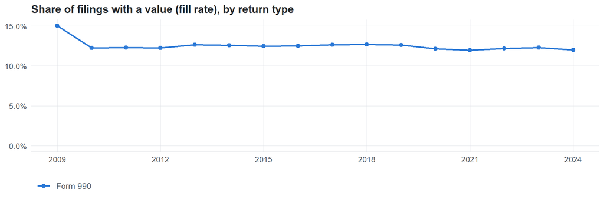

**Table view**

Table view: fill rate

| Tax year | Return type | Filings | All filings | Fill rate |
| --- | --- | --- | --- | --- |
| 2009 | Form 990 | 5,012 | 33,311 | 15.05% |
| 2010 | Form 990 | 15,085 | 123,025 | 12.26% |
| 2011 | Form 990 | 19,583 | 159,504 | 12.28% |
| 2012 | Form 990 | 22,011 | 179,688 | 12.25% |
| 2013 | Form 990 | 25,150 | 198,855 | 12.65% |
| 2014 | Form 990 | 27,473 | 218,619 | 12.57% |
| 2015 | Form 990 | 29,165 | 233,519 | 12.49% |
| 2016 | Form 990 | 30,466 | 243,903 | 12.49% |
| 2017 | Form 990 | 33,120 | 261,612 | 12.66% |
| 2018 | Form 990 | 34,415 | 271,442 | 12.68% |
| 2019 | Form 990 | 35,747 | 283,694 | 12.60% |
| 2020 | Form 990 | 38,866 | 320,342 | 12.13% |
| 2021 | Form 990 | 40,219 | 336,480 | 11.95% |
| 2022 | Form 990 | 42,496 | 349,055 | 12.17% |
| 2023 | Form 990 | 43,564 | 354,768 | 12.28% |
| 2024 | Form 990 | 33,264 | 277,298 | 12.00% |

## Repeating groups

Table cardinality in the concordance: **many**. 2 of 2 observed xpaths repeat within a filing.

Repeating element each xpath was observed in (from the raw indexed xpath)

| Xpath | Repeating element | Filings (summed over years) |
| --- | --- | --- |
| IRS990ScheduleI/RecipientTable/EINOfRecipient | (none) | 29128 |
| IRS990ScheduleI/RecipientTable/EINOfRecipient | IRS990ScheduleI/RecipientTable | 32563 |
| IRS990ScheduleI/RecipientTable/RecipientEIN | (none) | 197273 |
| IRS990ScheduleI/RecipientTable/RecipientEIN | IRS990ScheduleI/RecipientTable | 216672 |

## Values

| Result | Check | Detail |
| --- | --- | --- |
| ✓ pass | Values have the EIN format | 100.0% of values match ^999999999$ |
| ⚠ fail | Stored as text | data type is numeric: leading zeros and letters would be lost |
| ✓ pass | No placeholder values | no all-zero / all-nine placeholders among the most common values |
| ⓘ info | Leading zeros present | at least 1% of values start with 0 in some year, so numeric storage would change them |

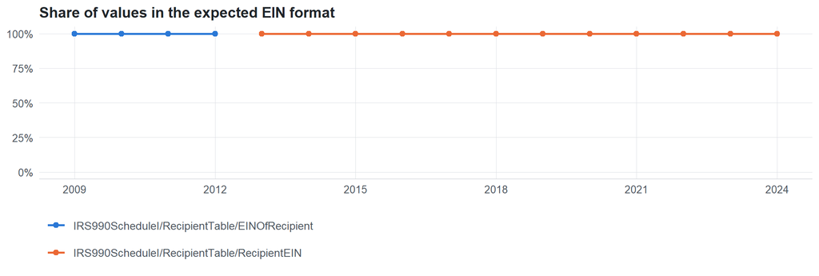

Value shapes (9 = digit, A = letter)

| Series | Shape | Expected | Filings |
| --- | --- | --- | --- |
| IRS990ScheduleI/RecipientTable/EINOfRecipient | 999999999 | yes | 61,691 |
| IRS990ScheduleI/RecipientTable/RecipientEIN | 999999999 | yes | 413,945 |

## Examples

| Tax year | Return | Xpath | Organization | Value | Source |
| --- | --- | --- | --- | --- | --- |
| 2024 | 990 | IRS990ScheduleI/RecipientTable/RecipientEIN | INTERNATIONAL BROTHERHOOD OF ELECTRICAL | 522257109 | [XML](https://gt990datalake-rawdata.s3.amazonaws.com/EfileData/XmlFiles/202503099349303295_public.xml) |
| 2023 | 990 | IRS990ScheduleI/RecipientTable/RecipientEIN | LOUISVILLE PROFESSIONAL FIREFIGHTERS | 131665552 | [XML](https://gt990datalake-rawdata.s3.amazonaws.com/EfileData/XmlFiles/202423209349320882_public.xml) |
| 2022 | 990 | IRS990ScheduleI/RecipientTable/RecipientEIN | ROTARY INTERNATIONAL SW WICHITA FALLS | 751101337 | [XML](https://gt990datalake-rawdata.s3.amazonaws.com/EfileData/XmlFiles/202421369349315972_public.xml) |
| 2021 | 990 | IRS990ScheduleI/RecipientTable/RecipientEIN | CAMP JOHN MARC FOUNDATION INC | 752205242 | [XML](https://gt990datalake-rawdata.s3.amazonaws.com/EfileData/XmlFiles/202241039349300339_public.xml) |
| 2020 | 990 | IRS990ScheduleI/RecipientTable/RecipientEIN | The CareSource Foundation | 311113395 | [XML](https://gt990datalake-rawdata.s3.amazonaws.com/EfileData/XmlFiles/202123169349306582_public.xml) |
| 2019 | 990 | IRS990ScheduleI/RecipientTable/RecipientEIN | Knights of Columbus | 311676315 | [XML](https://gt990datalake-rawdata.s3.amazonaws.com/EfileData/XmlFiles/202110719349300911_public.xml) |
| 2018 | 990 | IRS990ScheduleI/RecipientTable/RecipientEIN | BALTIMORE AFFORDABLE HOUSING | 526001394 | [XML](https://gt990datalake-rawdata.s3.amazonaws.com/EfileData/XmlFiles/202011979349308511_public.xml) |
| 2017 | 990 | IRS990ScheduleI/RecipientTable/RecipientEIN | UNITED WAY OF JOHNSON COUNTY INC | 530196605 | [XML](https://gt990datalake-rawdata.s3.amazonaws.com/EfileData/XmlFiles/201930759349300003_public.xml) |
| 2016 | 990 | IRS990ScheduleI/RecipientTable/RecipientEIN | Grove Education Foundation For | 736061035 | [XML](https://gt990datalake-rawdata.s3.amazonaws.com/EfileData/XmlFiles/201713079349300111_public.xml) |
| 2015 | 990 | IRS990ScheduleI/RecipientTable/RecipientEIN | INNOVATIVE SOLUTIONS NORTHWEST | 200032857 | [XML](https://gt990datalake-rawdata.s3.amazonaws.com/EfileData/XmlFiles/201611309349302226_public.xml) |
| 2014 | 990 | IRS990ScheduleI/RecipientTable/RecipientEIN | JUDGES AND LAWYERS BREAST CANCER ALERT | 136003018 | [XML](https://gt990datalake-rawdata.s3.amazonaws.com/EfileData/XmlFiles/201601249349301520_public.xml) |
| 2013 | 990 | IRS990ScheduleI/RecipientTable/RecipientEIN | NCS Community Development Corp | 161160170 | [XML](https://gt990datalake-rawdata.s3.amazonaws.com/EfileData/XmlFiles/201443019349300219_public.xml) |

## Reviewer checklist

- The definition matches the form line and instructions for every xpath’s schema years.
- Every xpath pooled here measures the same thing on the 990 and 990-EZ (close enough for analysis).
- The coverage chart has no unexplained gaps or jumps between tax years.
- Each open flag is fixed, or accepted with a note in validation_log.csv.
- The data type is text so leading zeros and letters survive.
- The identifier belongs to the entity the variable names (the filer, preparer, related organization…).
- Formats with and without punctuation (e.g. ZIP+4, dashes) are normalized consistently downstream.

Record the review as a row in `inst/extdata/src/validation_log.csv` (variable_name, reviewer, date, status, note). Evidence built 2026-09-23 17:09:04 MST from the ef2 DuckDB builds (tax years 2009–2024).